# HDAC inhibitor screen analysis

F. Heigwer

8/17/2018

## B110 Colors

```r
sgi_blue    = '#5087C8'
sgi_yellow1 = '#F2EE35'
sgi_yellow2 = '#FED98E'
b110_grey   = '#808080'
b110_grey_light   = '#909090'
b110_transparent_black = alpha('#000000',0.5)
google_red = '#dd4b39'
google_green = '#0F9D58'
google_yellow = '#F4B400'
google_blue = '#4285F4'
```

## Data input

Lets check how the data looks like and what the objectives of the analyses are.

```r
treat1<-read_delim(file = "../raw_data/counts_vorinostat_screen/Vorinostat1_S3_L001_R1_001.txt",delim = "\t")
treat2<-read_delim(file = "../raw_data/counts_vorinostat_screen/Vorinostat2_S4_L001_R1_001.txt",delim = "\t")
dmso1<-read_delim(file = "../raw_data/counts_vorinostat_screen/DMSO1_S1_L001_R1_001.txt",delim = "\t")
dmso2<-read_delim(file = "../raw_data/counts_vorinostat_screen/DMSO2_S2_L001_R1_001.txt",delim = "\t")
mydata<-treat1 %>%
  left_join(treat2) %>%
  left_join(dmso1) %>%
  left_join(dmso2) %>%
  extract(sgRNA,c("sgRNA","gene_id"),"((\\w+)_.*)") %>%
  gather(treatment,count,-sgRNA,-gene_id) %>%
  extract(treatment,c("treatment","replicate"),"(\\w+)_(\\d)")
anno<-read_delim("../meta_data/gene_names.txt",delim="\t")
```

## Lets do some data QC

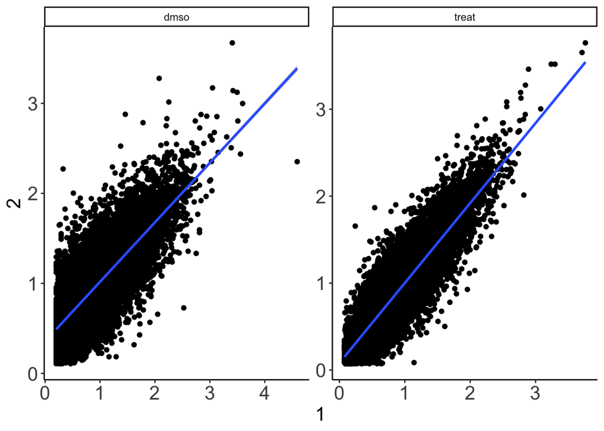

```
##
## Correlation method: 'pearson'
## Missing treated using: 'pairwise.complete.obs'
```

```
##
## Correlation method: 'pearson'
## Missing treated using: 'pairwise.complete.obs'
```

```
## $dmso
##   rowname   X1 X2
## 1       1
## 2       2  .78
##
## $treat
##   rowname   X1 X2
## 1       1
## 2       2  .89
```

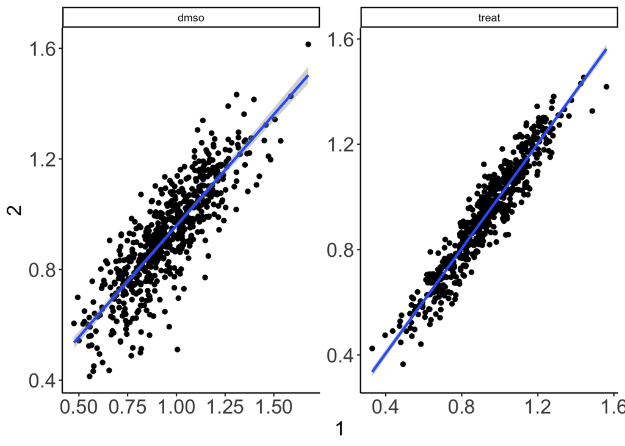

```
##
## Correlation method: 'pearson'
## Missing treated using: 'pairwise.complete.obs'
##
##
## Correlation method: 'pearson'
## Missing treated using: 'pairwise.complete.obs'
```

```
## $dmso
##   rowname   X1 X2
## 1       1
## 2       2  .84
##
## $treat
##   rowname   X1 X2
## 1       1
## 2       2  .95
```

## QC looks very nice and good so lets calls some foldchanges and hits thereof

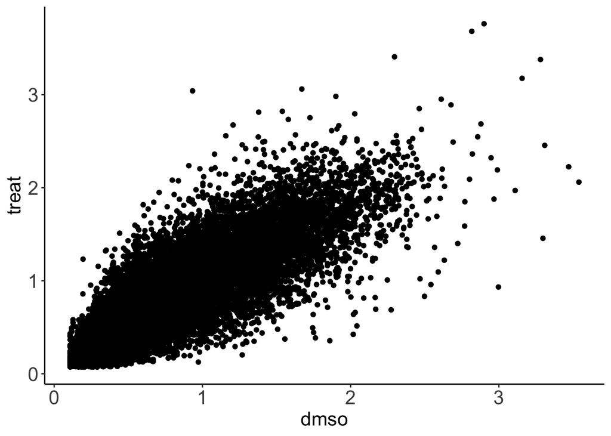

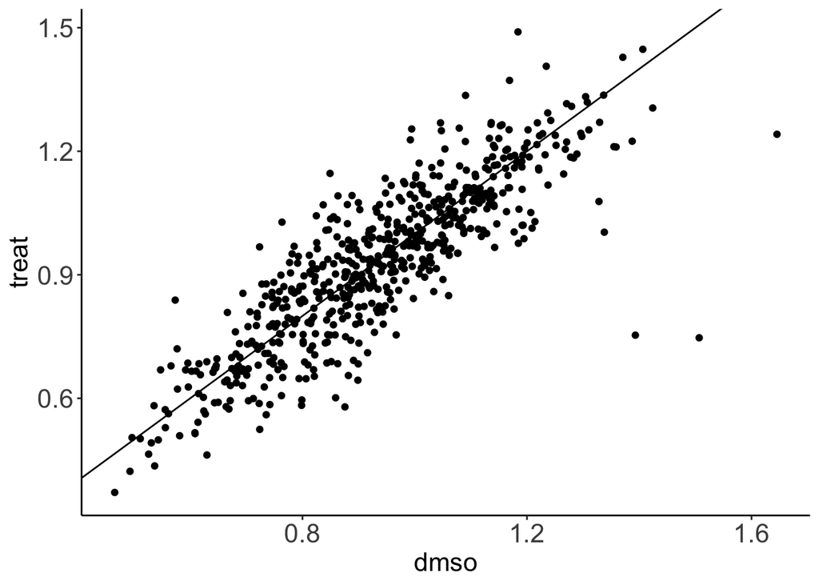

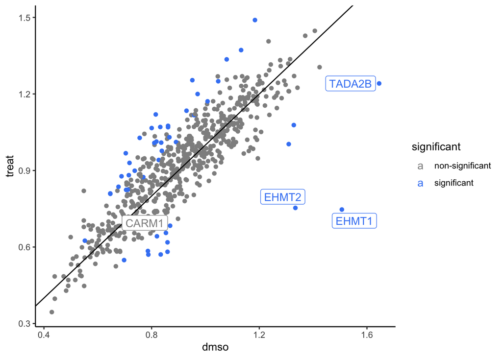

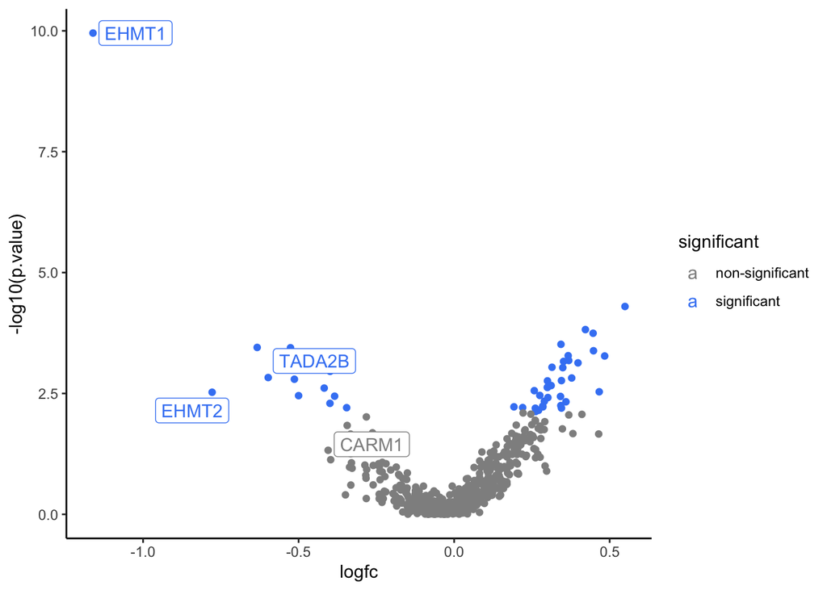

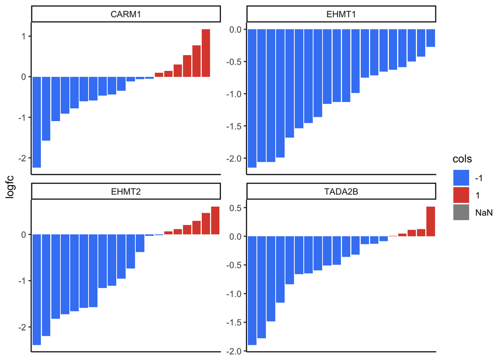

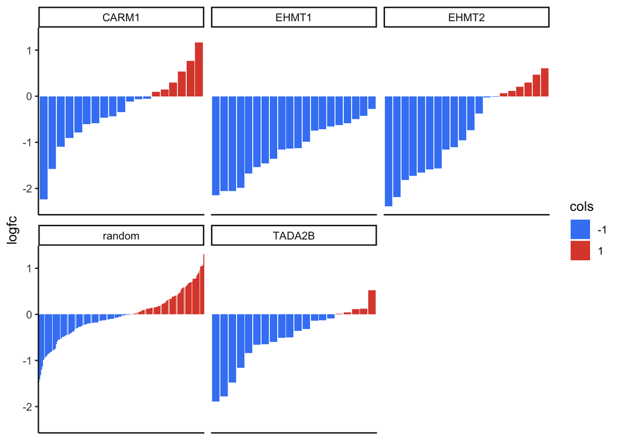

#try an alternaitve analysis using mageck

first we count the sgRNA abundance

mageck count -l library_design/chrom-modulators/chrom_mod.5.0.1.20.604.pos_list.1.0.1.20.17_short_oligos_final.mageck.txt -n vorinostat –sample-label LIB,DMSO1,DMSO2,V1,V2 –fastq raw_data/library_sequencing/chrom_modulators/5.0.1.20.604/fastq_raw/2171_CRISPR_CM5_Plasmid.fastq raw_data/reads_vorinostat_screen/2546_CRISPR_CM_DMSO1.fastq raw_data/reads_vorinostat_screen/2547_CRISPR_CM_DMSO2.fastq raw_data/reads_vorinostat_screen/2548_CRISPR_CM_Vorinostat1.fastq raw_data/reads_vorinostat_screen/2549_CRISPR_CM_Vorinostat2.fastq

second we calculate foldchagnes and significance using mageck RRA

mageck test -k vorinostat.count.txt -t V1,V2 -c DMSO1,DMSO2 -n vorinostat –control-sgrna meta_data/controls.sgRNA

third we test the DMSO vs library sample

then we read int the result

```r
mageck_result <- read_delim("../mageck_analysis/vorinostat.gene_summary.txt",delim = "\t") %>% left_join(anno %>% rename("id" = gene_id ))
```

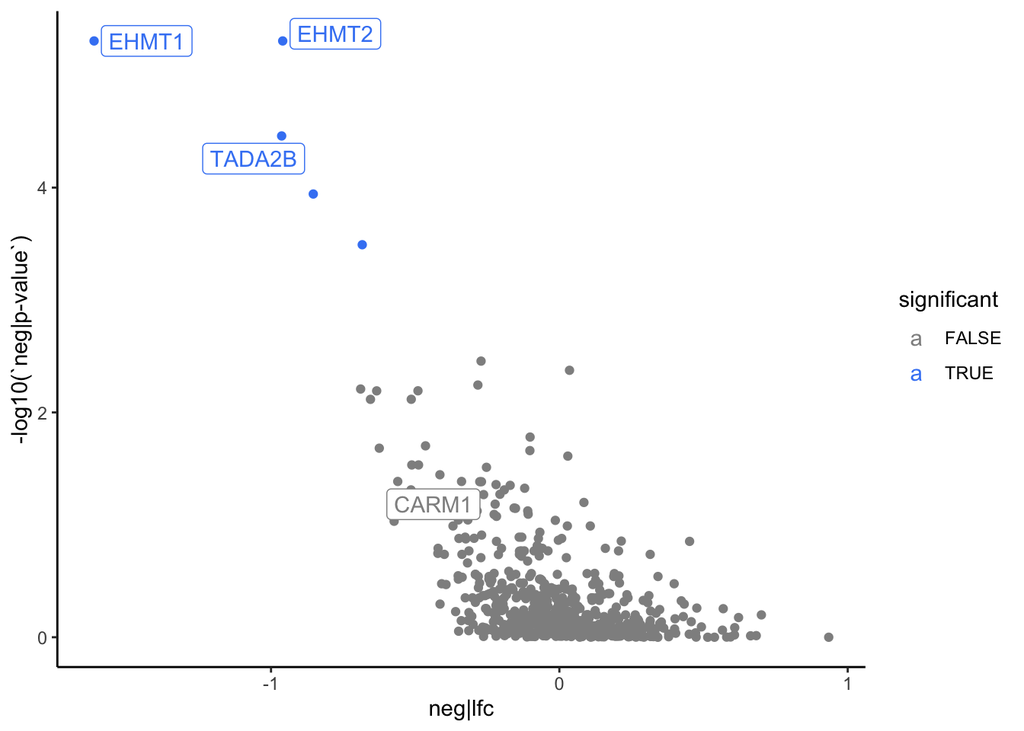

```r
#gene level
p1 <- mageck_result %>%
  mutate(labels=if_else(gene_symbol %in% c("EHMT1","EHMT2","CARM1","TADA2B"),gene_symbol,NA_character_),significant = if_else(`neg|fdr`<0.1,T,F)) %>%
  ggplot(aes(x=`neg|lfc`,y=-log10(`neg|p-value`),color=significant,label=labels)) +
    geom_point() +
    theme_classic() +
    geom_label_repel() +
    scale_color_manual(values = c(b110_grey_light,google_blue))

ggsave("../graphics/volcano_stat_colored_Vorinostat_mageck_neg_VORoverDMSO.pdf",width = 8,height = 8)
print(p1)
```

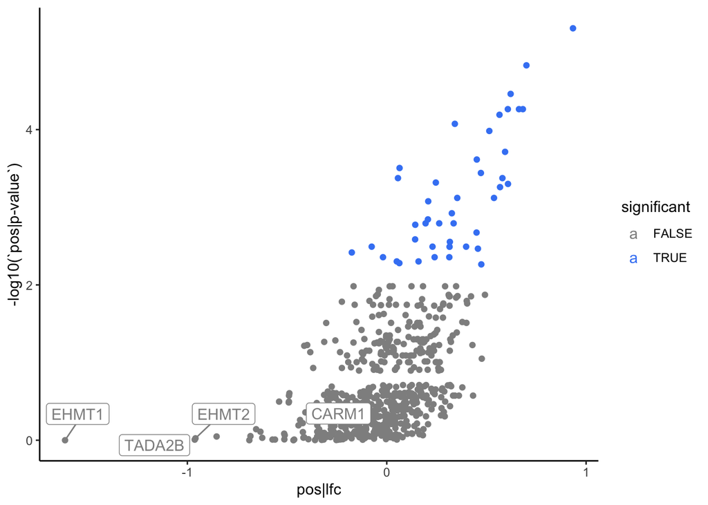

```r
#gene level
p1 <- mageck_result %>%
  mutate(labels=if_else(gene_symbol %in% c("EHMT1","EHMT2","CARM1","TADA2B"),gene_symbol,NA_character_),significant = if_else(`pos|fdr`<0.1,T,F)) %>%
  ggplot(aes(x=`pos|lfc`,y=-log10(`pos|p-value`),color=significant,label=labels)) +
    geom_point() +
    theme_classic() +
    geom_label_repel() +
    scale_color_manual(values = c(b110_grey_light,google_blue))

ggsave("../graphics/volcano_stat_colored_Vorinostat_mageck_pos_VORoverDMSO.pdf",width = 8,height = 8)
print(p1)
```

# DMSO vs Library

```r
mageck_result <- read_delim("../mageck_analysis/drop_out.gene_summary.txt",delim = "\t") %>% left_join(anno %>% rename("id" = gene_id ))
```

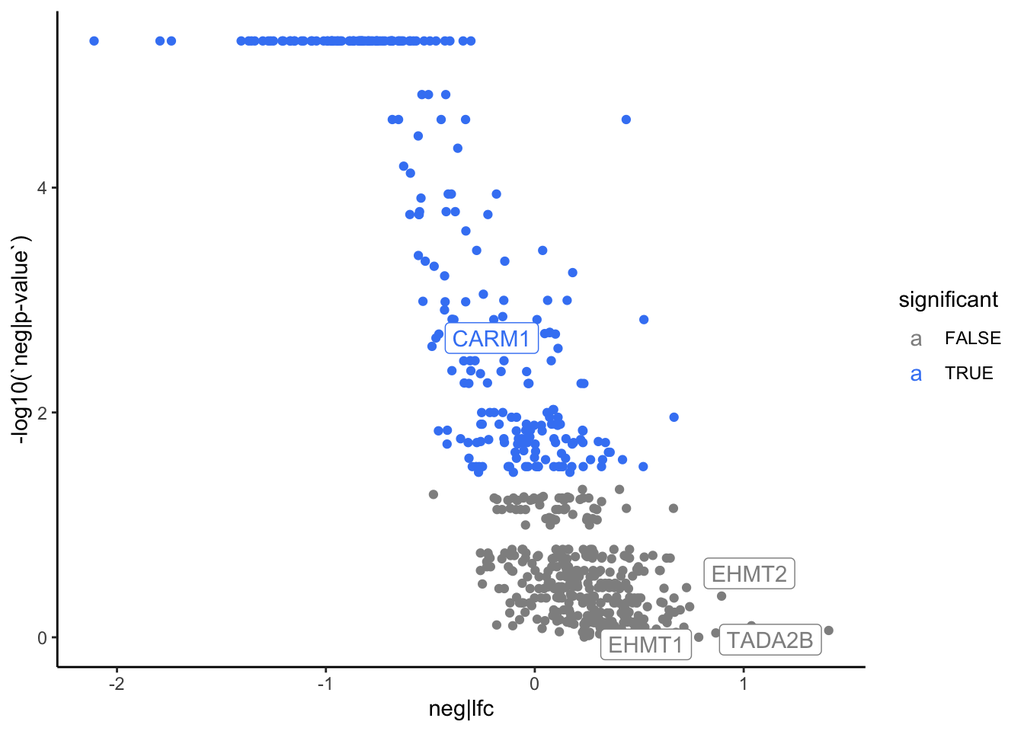

```r
#gene level
p1 <- mageck_result %>%
  mutate(labels=if_else(gene_symbol %in% c("EHMT1","EHMT2","CARM1","TADA2B"),gene_symbol,NA_character_),significant = if_else(`neg|fdr`<0.1,T,F)) %>%
  ggplot(aes(x=`neg|lfc`,y=-log10(`neg|p-value`),color=significant,label=labels)) +
    geom_point() +
    theme_classic() +
    geom_label_repel() +
    scale_color_manual(values = c(b110_grey_light,google_blue))

ggsave("../graphics/volcano_stat_colored_Vorinostat_mageck_neg_DMSOoverLIB.pdf",width = 8,height = 8)
print(p1)
```

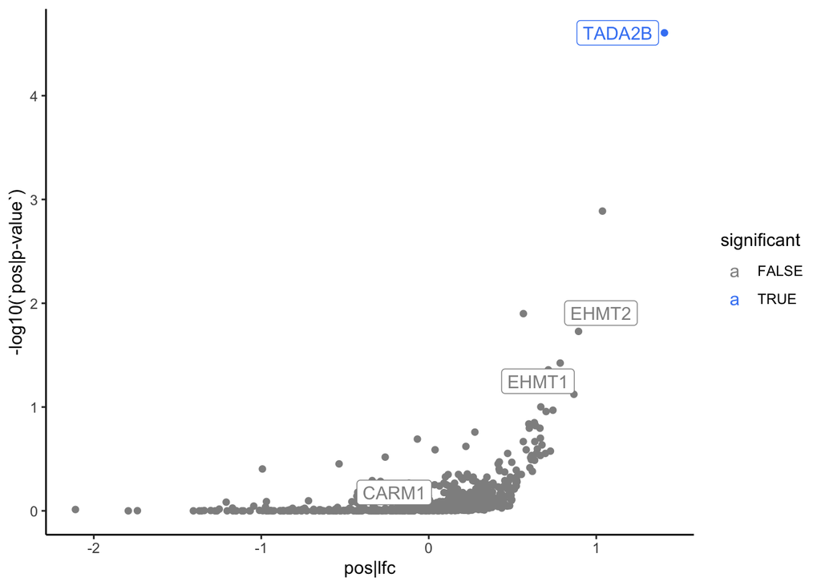

```r
#gene level
p1 <- mageck_result %>%
  mutate(labels=if_else(gene_symbol %in% c("EHMT1","EHMT2","CARM1","TADA2B"),gene_symbol,NA_character_),significant = if_else(`pos|fdr`<0.1,T,F)) %>%
  ggplot(aes(x=`pos|lfc`,y=-log10(`pos|p-value`),color=significant,label=labels)) +
    geom_point() +
    theme_classic() +
    geom_label_repel() +
    scale_color_manual(values = c(b110_grey_light,google_blue))

ggsave("../graphics/volcano_stat_colored_Vorinostat_mageck_pos_DMSOoverLIB.pdf",width = 8,height = 8)
print(p1)
```

# Session info

```r
writeLines(capture.output(sessionInfo()), paste("../results/SessionInfo_Vorinostat.txt",sep = ""))
```